# Informe Final

JHJ

# Introducció

A l’assignatura de Fonaments de la computació, acabem de veure que hi ha **problemes decidibles i indecidibles**, en aquest estudi podríem definir **el problema de l’ordenació d’un vector**, que **és clarament decidible**, ja que **hi ha $n$ algoritmes que el poden resoldre**, i a més, **els algoritmes operen en temps polinòmic**.

Entre aquests $n$ algoritmes que resolen el problema de l’ordenació d’un vector, en aquest estudi ens centrarem en només tres: **bubblesort** que és $O(n^2)$; **quicksort** que és $O(n \cdot log(n))$ en el millor i mitjà dels casos, però en el cas pitjor és $O(n^2)$ amb vectors ordenats; i **mergesort** que és $O(n \cdot log(n))$. Aquests dos últims algorismes *quicksort* i *mergesort* sabem per l’assignatura d’EDA que són algorismes de **divideix i venç**, per tant, *recursius*. En aquest estudi ens centrarem a respondre a la pregunta: **Quin algoritme és millor?**, entenent **millor** com: **Quin algoritme és més eficient?**

Durant l’estudi també sorgiran preguntes com: **Quina és la forma del temps d’execució?**, i després d’ajustar un model per cada algoritme entre el temps i la mida, sorgirà la pregunta: **Quina forma segueixen aquests errors?** Per respondre a cada pregunta farem servir conceptes de l’assignatura d’estadística.

# Descriptiva de les dades

## Resum estadístic

El nostre conjunt de dades es compon de dues taules, una conté informació de cadascun dels algoritmes que hem estudiat, (`algoritmes`).

```
## # A tibble: 3 × 3
##   algoritme  estable implementacio.recursiva
##   <chr>      <lgl>   <lgl>
## 1 bubblesort TRUE    FALSE
## 2 quicksort  FALSE   TRUE
## 3 mergesort  TRUE    TRUE
```

I una altra que conté informació del temps que ha trigat cada simulació amb cada algoritme, amb vectors de mides i ordenacions diferents, és a dir, amb vectors ordenats i desordenats, (`simulacions`), i podem descriure cada temps d’execució fent ser `summary()`.

```
##       mida            l_mida        bubblesort          quicksort
##  Min.   :  10.0   Min.   :2.303   Min.   :0.0000007   Min.   :1.000e-07
##  1st Qu.: 257.5   1st Qu.:5.551   1st Qu.:0.0004002   1st Qu.:8.000e-06
##  Median : 505.0   Median :6.225   Median :0.0015674   Median :1.750e-05
##  Mean   : 505.0   Mean   :5.940   Mean   :0.0020816   Mean   :1.826e-05
##  3rd Qu.: 752.5   3rd Qu.:6.623   3rd Qu.:0.0035004   3rd Qu.:2.770e-05
##  Max.   :1000.0   Max.   :6.908   Max.   :0.0084499   Max.   :1.226e-04
##    mergesort         ord.bubblesort      ord.quicksort
##  Min.   :8.000e-07   Min.   :0.0000004   Min.   :0.0000001
##  1st Qu.:2.480e-05   1st Qu.:0.0002319   1st Qu.:0.0000242
##  Median :5.220e-05   Median :0.0008848   Median :0.0000916
##  Mean   :5.362e-05   Mean   :0.0011761   Mean   :0.0001210
##  3rd Qu.:8.110e-05   3rd Qu.:0.0019674   3rd Qu.:0.0002033
##  Max.   :2.457e-04   Max.   :0.0049847   Max.   :0.0009996
##  ord.mergesort        l_bubblesort      l_quicksort       l_mergesort
##  Min.   :8.000e-07   Min.   :-14.172   Min.   :-16.118   Min.   :-14.039
##  1st Qu.:1.888e-05   1st Qu.: -7.823   1st Qu.:-11.736   1st Qu.:-10.605
##  Median :3.655e-05   Median : -6.458   Median :-10.953   Median : -9.860
##  Mean   :3.752e-05   Mean   : -7.030   Mean   :-11.281   Mean   :-10.148
##  3rd Qu.:5.630e-05   3rd Qu.: -5.655   3rd Qu.:-10.494   3rd Qu.: -9.420
##  Max.   :1.931e-04   Max.   : -4.774   Max.   : -9.007   Max.   : -8.311
```

D’aquí podem començar a respondre a la **pregunta inicial**. I podem dir que el **quicksort** és l’únic algoritme que **empitjora amb vectors ordenats el temps d’execució (en mitjana)**, mentre que **bubblesort** i **mergesort**, **milloren el temps d’execució amb vectors ordenats**. Per tant, **el millor algoritme seria aquell que** amb vectors ordenats millora o iguala la mitjana del temps, *obtinguda amb vectors desordenats*, o que manté la forma del temps, és a dir, **que és estable**.

Això mirant la mitjana, però també podríem mirar altres estadístics del `summary`. I també podria ser útil veure quina és la correlació entre el temps d’execució i la mida del vector.

```
## # A tibble: 1 × 6
##   bubblesort quicksort mergesort ord.bubblesort ord.quicksort ord.mergesort
##        <dbl>     <dbl>     <dbl>          <dbl>         <dbl>         <dbl>
## 1      0.965     0.946     0.957          0.966         0.953         0.950
```

I veiem que la variable dependent, **temps d’execució**, **té una correlació molt alta amb la variable independent, mida**.

## Visualització de dades

### Temps d’execució amb vectors ordenats i desordenats

Allò que hem dit de paraula, es veu millor si intentem veure-ho, visualitzant els temps de cada algoritme amb **vectors desordenats** i **vectors ordenats** amb un gràfic.

D’aquesta manera, podem veure **quina forma segueixen els temps d’execució de cada algoritme amb vectors ordenats i desordenats**, i podrem saber quin algoritme sembla més estable, és a dir, que manté la forma del temps, i a més també podrem veure la relació entre el temps d’execució i la mida del vector.

##### BubbleSort *desordenat*

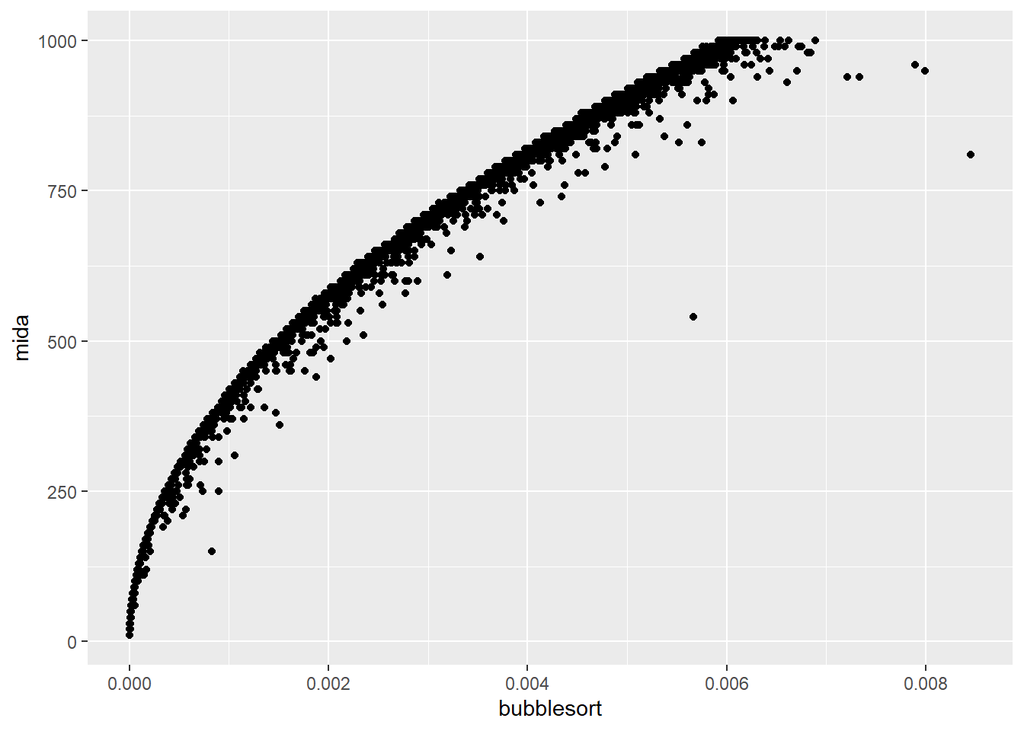

##### QuickSort *desordenat*

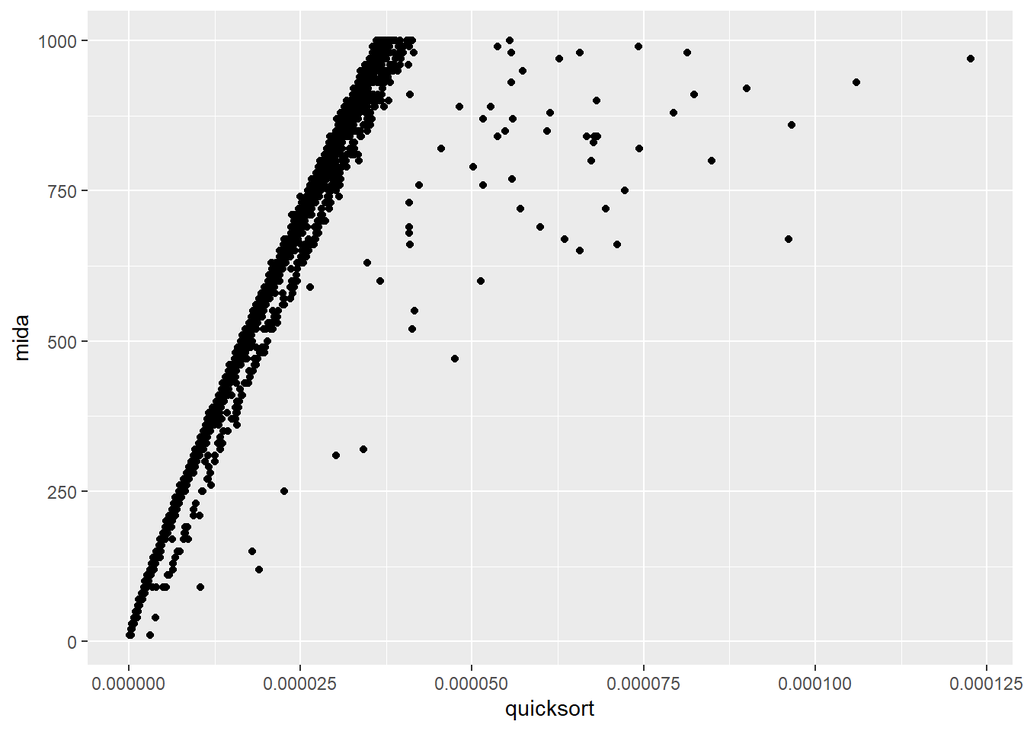

##### MergeSort *desordenat*

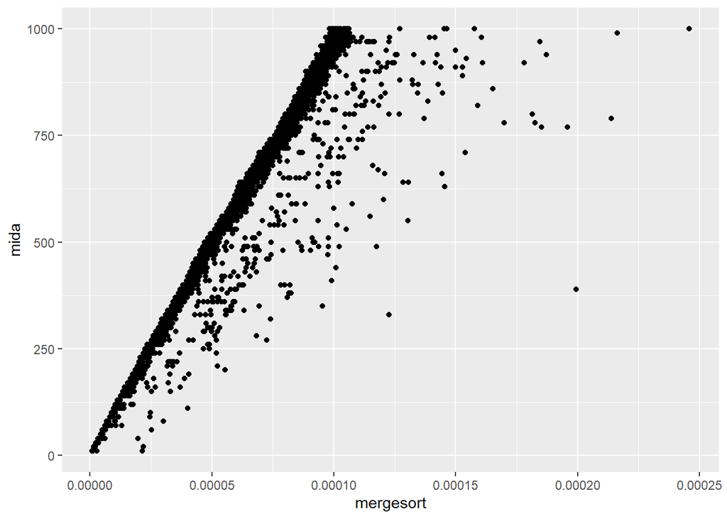

##### BubbleSort *ordenat*

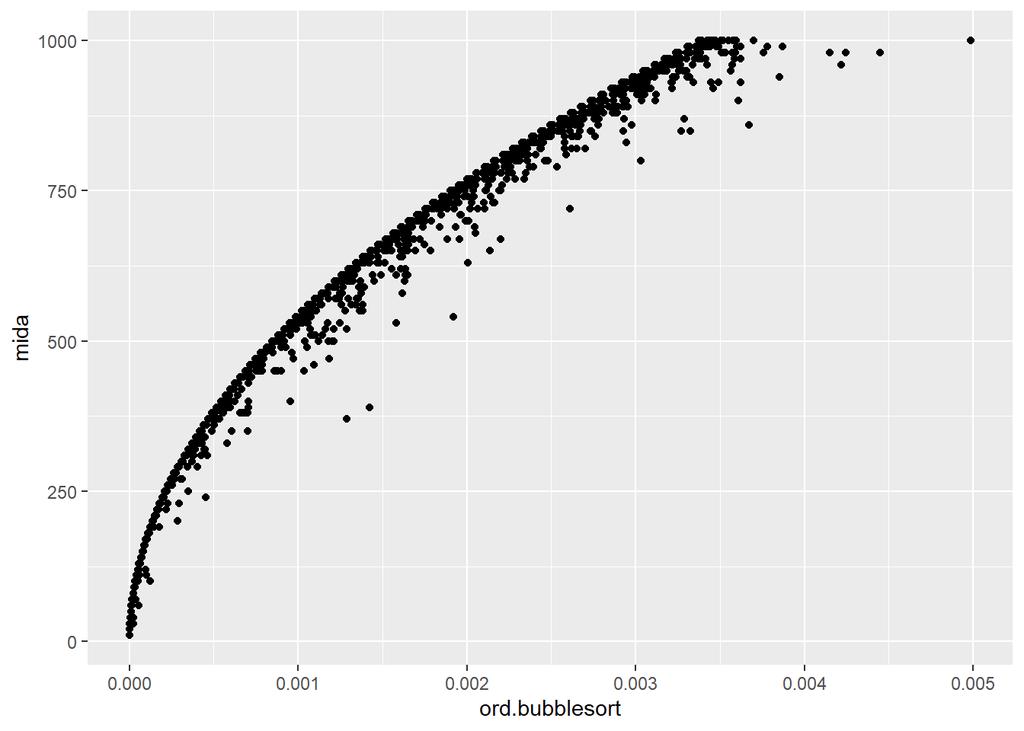

##### QuickSort *ordenat*

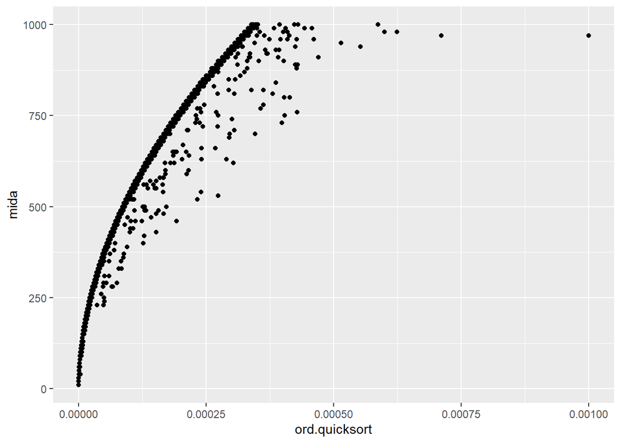

##### MergeSort *ordenat*

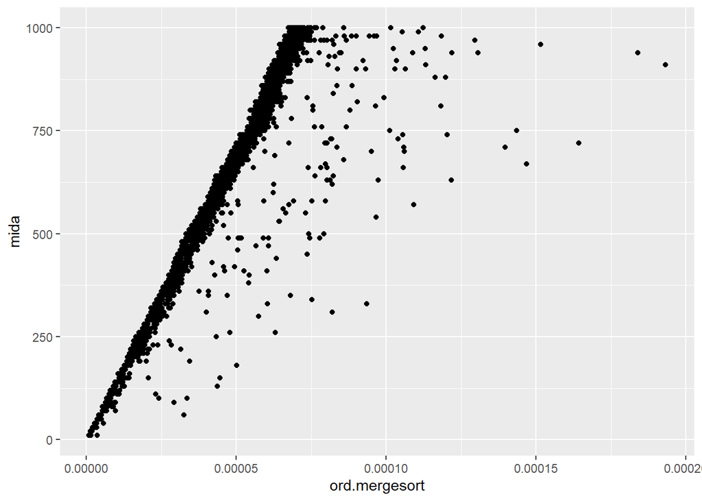

I podem veure que **bubblesort** i **mergesort** mantenen la forma amb els dos tipus de vectors, mentre **quicksort** amb **vectors desordenats es comporta com el mergesort**, i amb **vectors ordenats es comporta com el bubblesort**. Això té relació amb l’explicat a altres assignatures de programació com $MTP_{1 \lor 2} \lor EDA$.

A partir d’aquí ja hem respost la pregunta de quin algoritme sembla millor, *o més eficient*, en aquest cas **quicksort sembla millor**, però **mergesort és més estable**, és a dir, mergesort manté la forma del temps, **bubblesort també manté la forma**, però és de la forma $n^2$, mentre que **mergesort** és $n \cdot log(n)$.

# Hipòtesi plantejada

A continuació, ajustarem els següents models que ens ajudaran a plantejar la següent pregunta del nostre estudi, **quina és la forma dels errors**, aquesta és la pregunta en la qual se centra la major part de l’estudi, per tant, ajustarem els models. *Els models que hem ajustat treballen amb el logaritme del temps d’execució*.

```
## $lm.bubblesort
##
## Call:
## lm(formula = l_bubblesort ~ l_mida + I(l_mida^2), data = simulacions.res)
##
## Coefficients:
## (Intercept)       l_mida  I(l_mida^2)
##   -18.41690      1.81147      0.01733
##
##
## $lm.quicksort
##
## Call:
## lm(formula = l_quicksort ~ l_mida + I(l_mida * log(l_mida)),
##     data = simulacions.res)
##
## Coefficients:
##             (Intercept)                   l_mida  I(l_mida * log(l_mida))
##               -18.37137                  1.26795                 -0.04135
##
##
## $lm.mergesort
##
## Call:
## lm(formula = l_mergesort ~ l_mida + I(l_mida * log(l_mida)),
##     data = simulacions.res)
##
## Coefficients:
##             (Intercept)                   l_mida  I(l_mida * log(l_mida))
##               -15.99327                  0.86315                  0.06736
```

I podem veure la forma dels errors, *o residus*, visualitzant-los amb l’histograma.

### BubbleSort

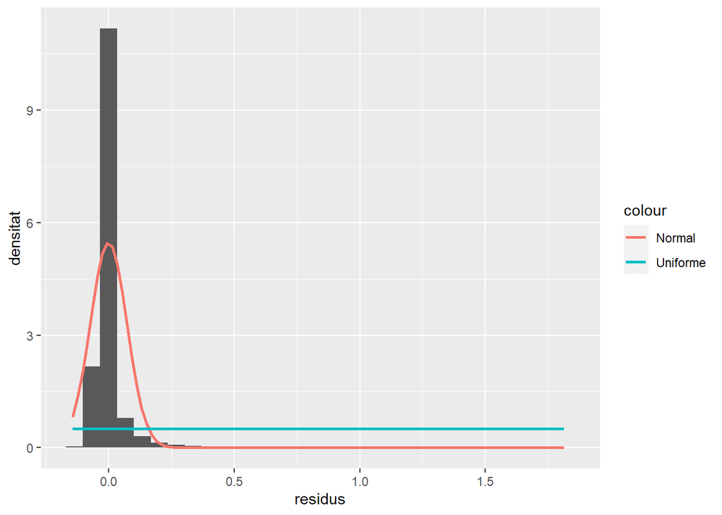

### QuickSort

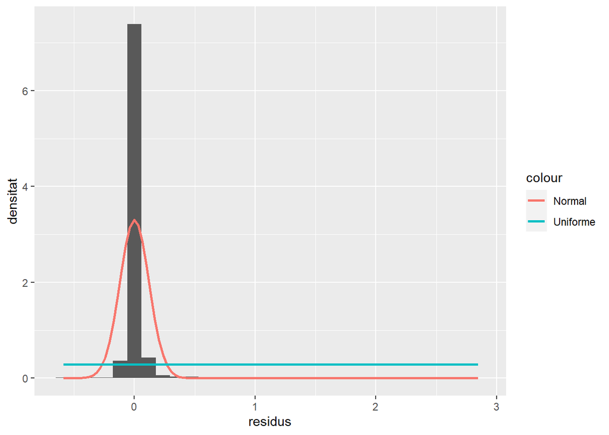

### MergeSort

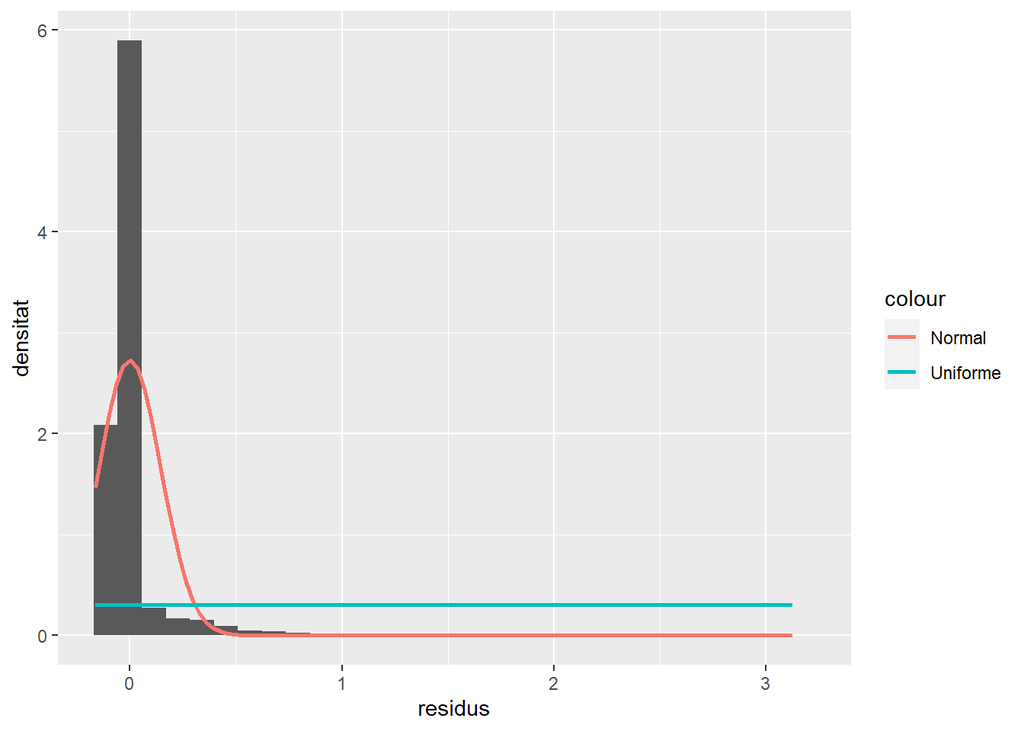

La nostra **hipòtesi plantejada** és si **hi ha una relació entre els errors dels models i la mida del vector**, i **quina és la forma d’aquests errors**, *treballant amb el logaritme del temps*.

> I per tenir ordenats els contrastos els hi podem assignar un codi. p.e. `[contrast de normalitat]`, pel contrast de normalitat, i `[contrast d'homocedasticitat]` pel contrast d’homocedasticitat.

El primer contrast, és el `[contrast de normalitat]`, per contrastar la normalitat dels residus.

$$H_0: \text{Els residus són normals}\\
H_1: \text{Els residus no són normals}$$

I el segón, és el `[contrast d'homocedasticitat]`, per contrastar l’homocedasticitat dels residus.

$$H_0: \text{Els residus són homocedastics}\\
H_1: \text{Els residus no són homocedastics}$$

Per **respondre a la nostra hipòtesi també podem obtenir intervals de confiança**, i amb aquests intervals podem veure si **els residus són més normals**, o no, o si segueixen una certa forma.

**Utilitats:**

Per tal **construir intervals de confiança amb R**, hem programat la següent funció (`confidence.intervals`), que a partir d’una mostra, si no és pot assumir normalitat fa servir el **mètode de bootstrap**, altrament, si pot fer servir la **$t$-student**, la fa servir, altrament, fa servir el **teorema del límit central**. D’aquesta forma **el procés de construir intervals queda automatitzat en una funció**.

```
## function(mostra, normalitat = FALSE, t.student = FALSE) {
##   # si assumim normalitat apliquem la t-student
##   if (normalitat) {
##     if (t.student) {
##       sort(mean(mostra) + qt(.025,length(mostra)-1) * c(-1,1) * sd(mostra) / sqrt(length(mostra)))
##     } else {
##       c(qnorm(.025, mean = mean(mostra), sd = sd(mostra)/(sqrt(length(mostra)))),
##         qnorm(.975, mean = mean(mostra), sd = sd(mostra)/(sqrt(length(mostra)))))
##     }
##   } else {
##     # si no fem servir el mètode de bootstrap
##     res = replicate(length(mostra), mean(sample(mostra,length(mostra), replace = TRUE)))
##     quantile(res, c(.025,.975))
##   }
## }
```

> També tenim una funció per mostrar l’histograma, i altres funcions d’R que ens permeten automatitzar més tasques repetitives.

# Assumpcions seguides

L’assumpció més important que hem seguit, i que hem contrastat en el primer apartat d’aquest informe, és que la variable **temps** i la variable **mida**, **tenen una correlació molt alta**, i això és possible, ja que el **temps** s’ha obtingut a partir de vectors de diferents **mides**, o dit d’una altra manera, la variable **temps** és una variable dependent, i la variable **mida** és una variable independent.

Hem seguit altres assumpcions, p.e. relacionades amb el `[contrast de normalitat]`. Per tal d’estudiar els errors, com que **no podem assumir normalitat dels residus**, podem dir, pel **teorema del límit central**, almenys la nostra mostra és bastant gran.

```
## [1] 5000   12
```

Com que **la nostra mostra és bastant gran segons el teorema**, llavors podem assumir que **la mitjana de la mostra segueix una normal** com.

$$\overline{X} \approx N(\mu_x, \frac{\sigma_x}{\sqrt{n}})$$

Assumpcions del `[contrast d'homocedasticitat]`.

Altres assumpcions, hem vist que **no podem assumir una normal**, i tot i que **veient els gràfics ens pugui semblar que els residus són homoscedastics**, **tampoc tenim evidències per assumir l’homoscedasticitat dels residus**.

# Resultats i conclusió

Per donar resposta al contrast `[contrast de normalitat]`, podem fer servir la funció `shapiro.test()`.

```
##
##  Shapiro-Wilk normality test
##
## data:  residuals(mods.log$lm.bubblesort)
## W = 0.46104, p-value < 2.2e-16
```

```
##
##  Shapiro-Wilk normality test
##
## data:  residuals(mods.log$lm.quicksort)
## W = 0.37467, p-value < 2.2e-16
```

```
##
##  Shapiro-Wilk normality test
##
## data:  residuals(mods.log$lm.mergesort)
## W = 0.45389, p-value < 2.2e-16
```

Amb un nivell de significació de $\alpha = 0.05$, podem veure que el $valor-p < \alpha$, per tant, **tenim evidències per rebutjar la normalitat dels residus**.

Per donar resposta al contrast `[contrast d'homocedasticitat]`, podem fer servir la funció `bptest()`, en aquest test no li passem els residus, sinó que li hem de passar els models directament.

```
##
##  studentized Breusch-Pagan test
##
## data:  mods.log$lm.bubblesort
## BP = 15.05, df = 2, p-value = 0.0005394
```

```
##
##  studentized Breusch-Pagan test
##
## data:  mods.log$lm.quicksort
## BP = 80.38, df = 2, p-value < 2.2e-16
```

```
##
##  studentized Breusch-Pagan test
##
## data:  mods.log$lm.mergesort
## BP = 60.152, df = 2, p-value = 8.671e-14
```

Amb un nivell de significació de $\alpha = 0.05$, podem veure que el $valor-p < \alpha$, per tant, **tenim evidències per rebutjar l’homocedasticitat dels residus**. En conclusió, **els residus són heterocedastics**, és a dir, que segueixen una tendència.

Com que els resultats del `[contrast de normalitat]` i del `[contrast d'homocedasticitat]` ens han portat a rebutjar la hipòtesi nul·la, podem provar de construir intervals de confiança per veure si podem assumir algun contrast.

Aquests intervals els podem construir fent servir la funció `confidence.intervals()`, i com que no podem assumir normalitat dels residus, haurem de fer servir el mètode de bootstrap, és a dir, executar la funció `confidence.intervals(residus)`, canviant els residus pels residus dels models.

```
## # A tibble: 2 × 3
##   bubblesort quicksort mergesort
##        <dbl>     <dbl>     <dbl>
## 1   -0.00192  -0.00323  -0.00413
## 2    0.00200   0.00359   0.00418
```

I tornem a contrastar `[contrast de normalitat]` i `[contrast d'homocedasticitat]` amb les funcions `shapiro.test()` i `bptest()` respectivament.

```
##
##  Shapiro-Wilk normality test
##
## data:  residuals(mods.log$lm.bubblesort)[between(residuals(mods.log$lm.bubblesort), int$bubblesort[1], int$bubblesort[2])]
## W = 0.95265, p-value = 3.108e-07
```

```
##
##  Shapiro-Wilk normality test
##
## data:  residuals(mods.log$lm.quicksort)[between(residuals(mods.log$lm.quicksort), int$quicksort[1], int$quicksort[2])]
## W = 0.96102, p-value = 2.87e-07
```

```
##
##  Shapiro-Wilk normality test
##
## data:  residuals(mods.log$lm.mergesort)[between(residuals(mods.log$lm.mergesort), int$mergesort[1], int$mergesort[2])]
## W = 0.94013, p-value = 4.022e-07
```

Treballant amb el mateix nivell de significació ($\alpha = 0.05$). El $valor-p < \alpha$, per tant, continuem sense poder assumir normalitat dels residus.

I no podem respondre el `[contrast d'homocedasticitat]`, ja que a la funció `bptest()` li pasem els models ajustats, de totes maneres si **no podem assumir homocedasticitat ni normalitat** dels residus, **els intervals de confiança no ens aporten res de nou**.

# Anàlisi de resultats

El `[contrast de normalitat]` i el `[contrast d'homocedasticitat]` ens han donat un $valor-p < \alpha$, on $\alpha = 0.05$. Per tant, no podem assumir normalitat dels residus, i els intervals de confiança tampoc ens aporten res de nou, per tant, podem dir que **els residus dels models ajustats no són normals**. Sí que podem dir que **la mitjana segueix una normal**, *pel teorema del límit central*.

I tot i que el `[contrast d'homocedasticitat]` ens diu que **els residus no són homocedastics**, en realitat **ho semblen bastant**.

### BubbleSort

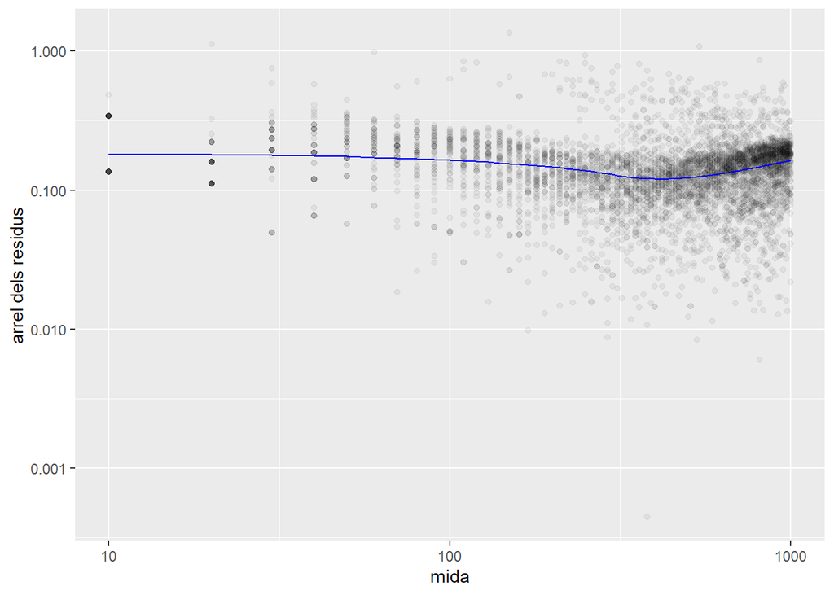

### QuickSort

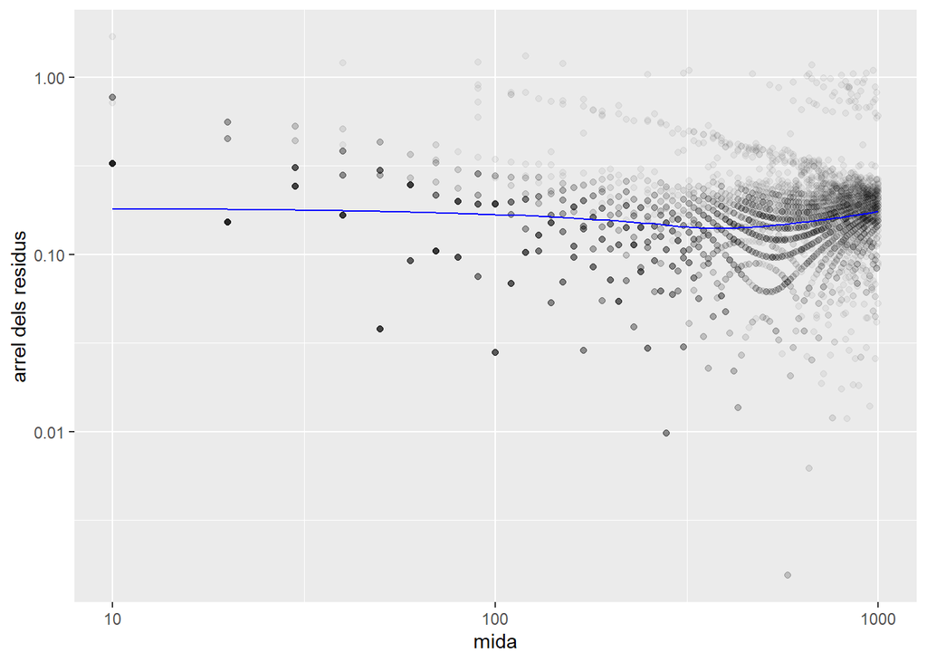

### MergeSort

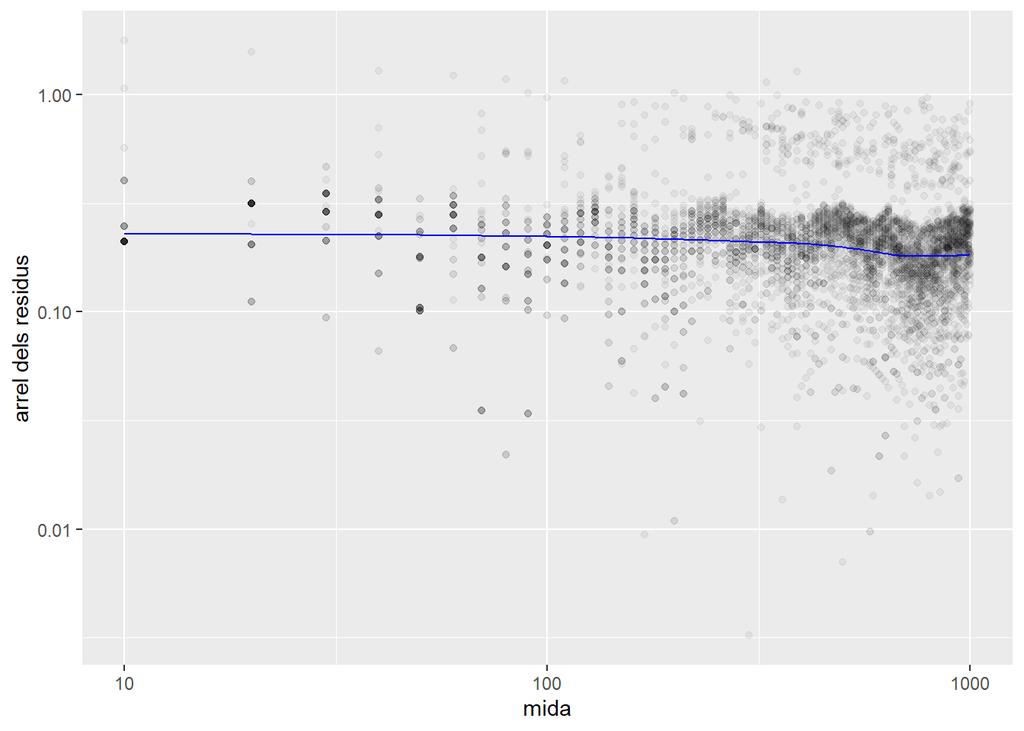

Finalment, observant els gràfics veiem que **no semblen seguir cap tendència**, tot i que **el test d’homocedasticitat ens dona un $valor-p < \alpha$**. Potser devem estar veient un **error tipus 1**, rebutjar $H_0$ quan és certa, en tot cas hauríem de calcular la $P(\text{rebutjar }H_0 | H_0\text{ és certa})$.

I a partir d’aquí, podem pensar que **els errors es poden ajustar a una** `skew normal`.

### BubbleSort

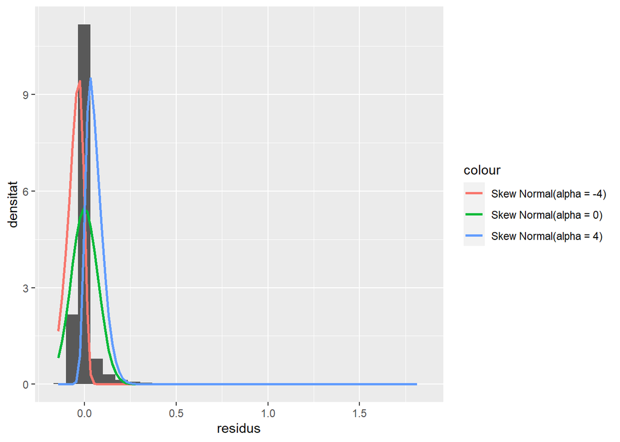

### QuickSort

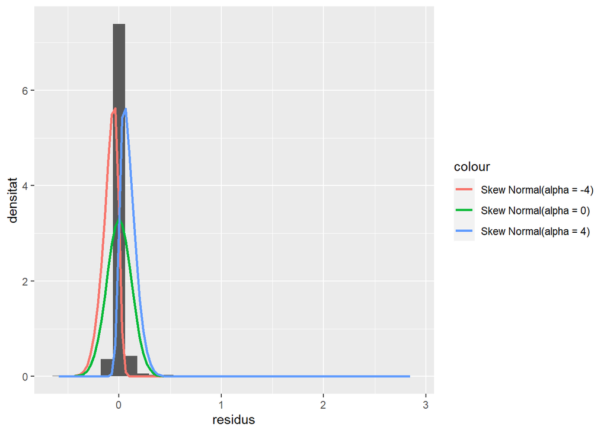

### MergeSort

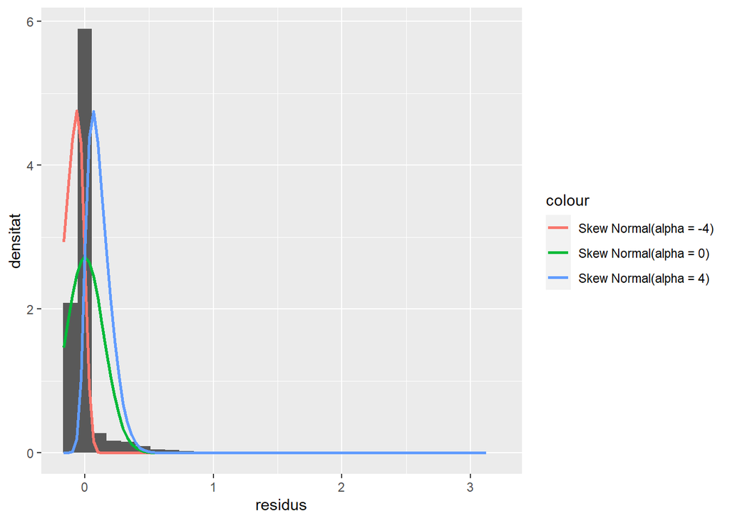

## Conclusió

Finalment, la conclusió final és que **els residus dels temps dels diferents algoritmes estudiats segueixen la forma que han de seguir segons la teoria**, p.e. **bubblesort és $O(n^2)$** és el que aplicant la transformació logarítmica sembla **seguir més una normal**, mentre que **el quicksort i el mergesort amb la forma $O(n \cdot log(n))$ segueixen més el logaritme que una normal**. I quan diem que el bubblesort segueix una normal, en realitat volem dir que segueix una normal amb un biaix cap al 0, *cap a l’esquerra*, o una skew normal amb $\alpha \pm 4$, encara que tampoc semblen seguir aquesta distribució. En realitat **els residus segueixen el logaritme**, a conseqüència de la transformació logarítmica dels temps, que hem fet a l’inici de l’estudi.

## Referències

- `[DiarisEstadistica]`. Grup JHJ. (2024). *Diaris d’estadistica*. Estadistica, GEINF, UdG.
- `[apuntsEstadistica]` Professors d’estadistica. (2024). *Apunts del moodle*. Estadistica, GEINF, UdG.
- `[apuntsEDA]` Professors de EDA. (2023). *Apunts del moodle de EDA*. EDA, GEINF, UdG.
- `[apuntsMTP]` Professors de $MTP_{1 \lor 2}$. (2022). *Apunts del moodle de MTP1 i MTP2*. $MTP_{1 \lor 2}$, GEINF, UdG.